# Fitting variables tutorial

R.Bunn

28-February-2021

# Learning Goals

- Understand why fitting a variable back onto an ordination space may be useful
- Learn to use `envfit()` from ‘vegan’ package to fit variables onto ordination plots
- Learn how to extract information from `envfit()` for plotting

# Getting Started

Install and require all the packages you will need to run the code.

```r
# Required for tutorial:
library(ape) # for pcoa()
library(vegan) # for dune, dune.env, metaMDS(), envfit()
library(ggplot2) # for ggplot()
library(PNWColors)
```

## Set.seed

Each call to nMDS will produce a unique run. I will `set.seed()` within each chunk that has a random process. It seems like there must be a better way to do this, but I don’t know what it is!

## Data

We will continue to use the ‘dune’ dataset. See the PCoA tutorial for more information about this dataset.

```r
# dune
data(dune)
data(dune.env)
```

# Introduction

We have learned three different methods for unconstrained ordination:

- PCA
- PCoA
- nMDS

Each of these methods has the same goal of describing a multidimensional dataset in a lower dimensional space. Each sample unit is given coordinates for its location in this new space.

Often we are interested in how one or more additional variables, *not the variables in the original data set*, are represented in that new space. This can help us understand how other variables may either co-vary with, or perhaps even cause, patterns that we observe in our response variables. We have a variety of options at our disposal, and we can explore multiple options to confirm that we consistently come to the same understanding of our data.

Some possible approaches:

1. If the variable is a factor (i.e. categorical) we can
   - represent the variable as a property of the symbol (e.g. via shapes, discrete colors)
   - identify the centroid of all samples with the same level of the variable (e.g. using `envfit()` or `ordibar()`).
2. If the variable is numeric, we can
   - represent the variable as a proprety of the symbol (e.g. via a color gradient, size)
   - display a vector that represents the linear regression of the variable on the ordination space (e.g. using `envfit()`)
   - display a surface that represents the nonlinear regression of the variable on the ordination (e.g. using `ordisurf()`)

We have already learned how to use shapes, discrete colors and color gradients to display other variables on our plots. In this tutorial we will learn how to find the centroids of factor variables and the vectors of numeric variables in ordination space and represent this information on an ordination plot.

# Using `envfit()`

The function `envfit()` takes an ordination object and an ‘environmental’ variable object (dataframe, matrix, or vector). These variables can be categorical or numerical and are *not* part of the response variable matrix that was used to create the ordination. The function returns information about how the variables fit onto the ordination space.

## Vector variables

Because the ordination space is metric, we can regress our metric ‘environmental’ numeric variables onto that ordination space. This is just a regular linear regression. Each sample unit has value of the environmental variable and coordinates of MDS1 and MDS2 (and optionally MDS3 if included). We can use these values to find the direction of steepest change across our ordination space.

$EnvVariable = \beta_1*MDS1 + \beta_2*MDS2$

The `envfit()` function returns the endpoint of a vector which points in the direction of steepest change of the environmental variable and which has maximum correlation with the ordination space. In addition, a $R^2$ value and a permutational p-value to help us determine which ‘environmental’ variables are useful.

## Factor variables

The average values of the ordination scores for each factor level are returned. Again, the `envfit()` function returns a $R^2$ value ($1 - SS_{within}/SS_{total}$) and a permutational p-value to help us determine which ‘environmental’ variables are useful.

## nMDS ordination

Before we can fit variables, we must first create an ordination space.

The function we are using, `envfit()` can easily handle with an ordination objects created within vegan, but it can also handle output from other ordination functions, we will demonstrate this below with output from a PCoA run with `pcoa()`.

We will run a nMDS of the dune dataset with two axes. Explanation of this function and interpretation of the output can be found in the nMDS Tutorial.

```r
set.seed(1)
dune.nmds <- metaMDS(dune,  k=2, trace = FALSE)
dune.nmds
```

```
##
## Call:
## metaMDS(comm = dune, k = 2, trace = FALSE)
##
## global Multidimensional Scaling using monoMDS
##
## Data:     dune
## Distance: bray
##
## Dimensions: 2
## Stress:     0.1183186
## Stress type 1, weak ties
## Two convergent solutions found after 20 tries
## Scaling: centring, PC rotation, halfchange scaling
## Species: expanded scores based on 'dune'
```

Running `envfit()` with a `vegan` ordination object is easy. We can quickly see that soil thickness (A1), Moisture, Management, and Manure are all ‘significant’. These variables are likely correlated as Management would influence that amount of Manure applied, which would in turn effect the soil thickness and moisture. These variables all fit together in a logical way with the patterns of plant communities in this space. Therefore we have increased confidence that the patterns we observe here are real.

```r
set.seed(1)
?envfit
my.fit <- envfit(dune.nmds, dune.env)
my.fit
```

```
##
## ***VECTORS
##
##      NMDS1   NMDS2     r2 Pr(>r)
## A1 0.96474 0.26321 0.3649  0.014 *
## ---
## Signif. codes:  0 '***' 0.001 '**' 0.01 '*' 0.05 '.' 0.1 ' ' 1
## Permutation: free
## Number of permutations: 999
##
## ***FACTORS:
##
## Centroids:
##                NMDS1   NMDS2
## Moisture1    -0.5101 -0.0403
## Moisture2    -0.3938  0.0139
## Moisture4     0.2765 -0.4033
## Moisture5     0.6561  0.1476
## ManagementBF -0.4534 -0.0102
## ManagementHF -0.2636 -0.1282
## ManagementNM  0.2958  0.5790
## ManagementSF  0.1506 -0.4670
## UseHayfield  -0.1568  0.3248
## UseHaypastu  -0.0412 -0.3370
## UsePasture    0.2854  0.0844
## Manure0       0.2958  0.5790
## Manure1      -0.2482 -0.0215
## Manure2      -0.3079 -0.1866
## Manure3       0.3101 -0.2470
## Manure4      -0.3463 -0.5582
##
## Goodness of fit:
##                r2 Pr(>r)
## Moisture   0.5014  0.001 ***
## Management 0.4134  0.004 **
## Use        0.1871  0.122
## Manure     0.4247  0.018 *
## ---
## Signif. codes:  0 '***' 0.001 '**' 0.01 '*' 0.05 '.' 0.1 ' ' 1
## Permutation: free
## Number of permutations: 999
```

## nMDS Quick plots

It is nice to see how these variables look in the ordination space and we can use baseR to make a quick plot.

### Quickest

This is a bit messy but it is fast and informative!

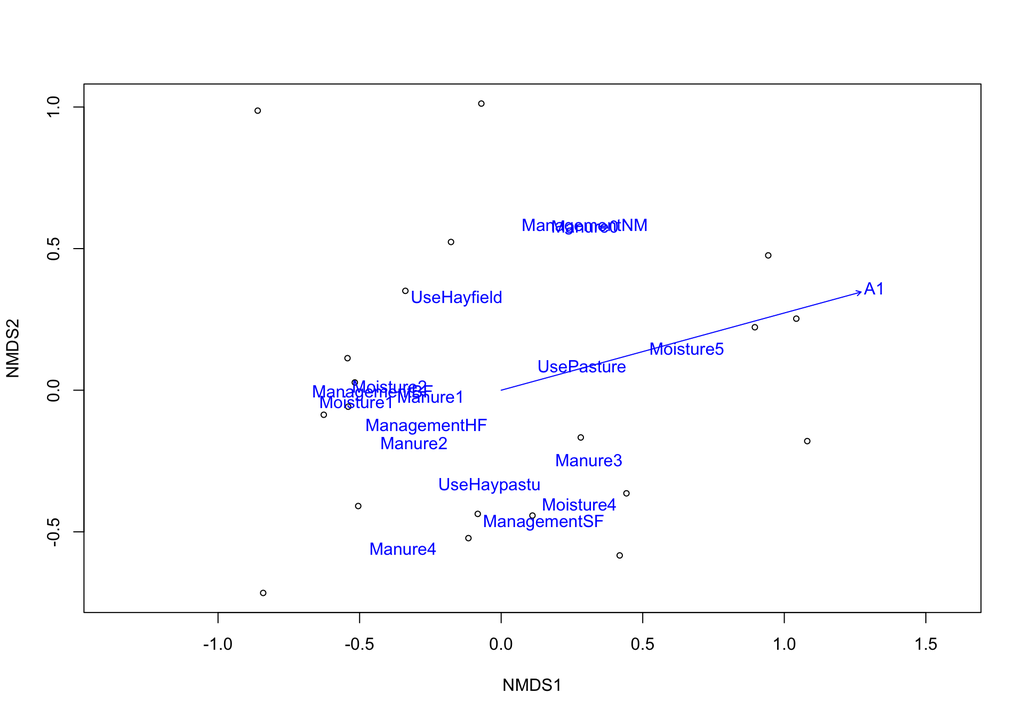

```r
plot(dune.nmds, display = "sites")
plot(my.fit)
```

### Remove ‘non-significant’

That is better (and red!), but still a bit of a mess. We will look at how we can pull the information out of envfit so we can make plots just the way we want to.

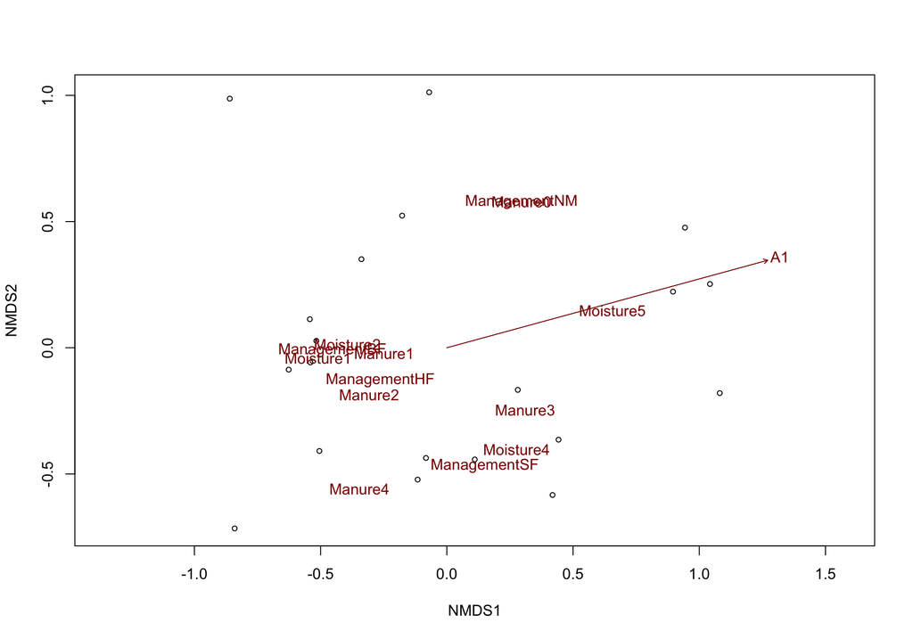

```r
plot(dune.nmds, display = "sites")
plot(my.fit, p.max = 0.05, col = "darkred")
```

## PCoA ordination

We will also run a PCoA of the dune dataset and retain two axes. Explanation of this function and interpretation of the output can be found in the PCoA Tutorial.

```r
my.dist <-vegdist(dune)
dune.pcoa <- pcoa(my.dist)
```

## PCoA Quick plot

If we want to use envfit with a non-vegan ordination object, we just need to extract the scores first. Although this is a different ordination space, and the sites are located slightly differently, the overall patterns and relationships of the ‘environmental’ variables are similar. The interpretation would be the same.

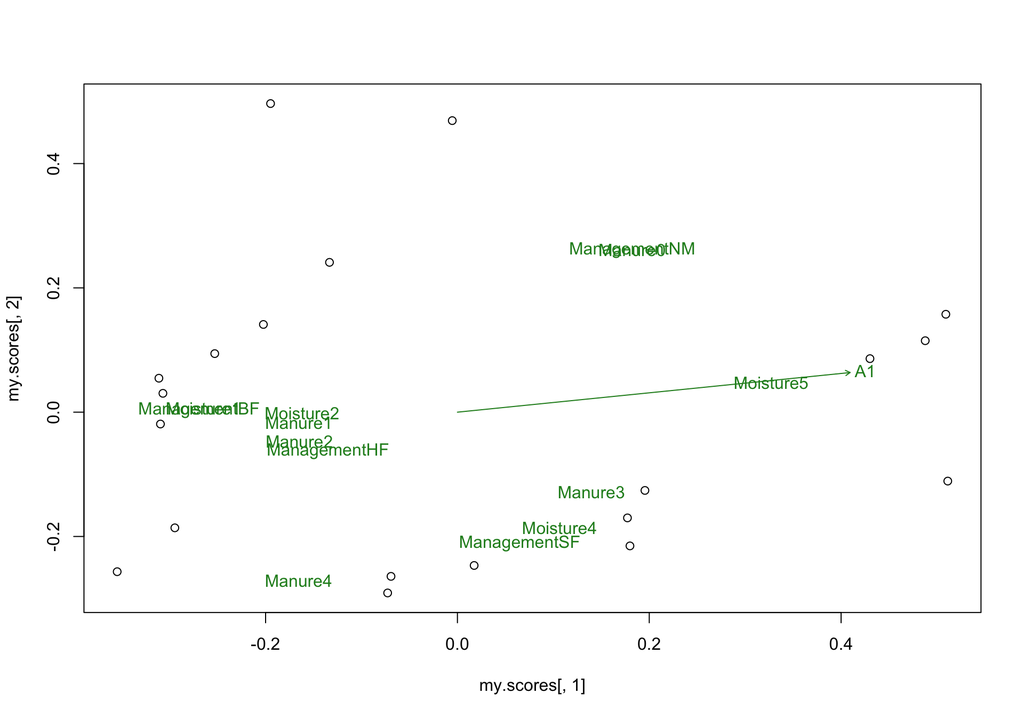

```r
my.scores <- dune.pcoa$vectors[,1:2]
mypcoa.fit <- envfit(my.scores, dune.env)
plot(x = my.scores[,1],
     y = my.scores[,2])
plot(mypcoa.fit, p.max = 0.05, col="forestgreen")
```

## Extracting from envfit

The `envfit()` output contains information on the arrows and centroids of variables that were fit to the ordination. However, extracting that information from the `envfit()` object requires a few steps. We will walk through those steps and save this information in two separate objects, one with the information for on the factors, ‘facPlot’, and the other with information on the vectors, ‘vecPlot’.

#### Vectors

Note, the vector segments are reported in the `envfit()` output are the unit length vectors. But, before plotting, these vectors are scaled so that variables that are more strongly correlated with the data have longer segments and so the arrows ‘fill the plot space’. This happens in two steps.

1. Each vector is multiplied by the square root of its $r^2$
2. All vectors are then scaled to ‘fill the plot’

We will retain (1), but not (2).However, if we want to, we can scale the arrows in our plot by multiplying them all by the same scaling factor. Direction and relative length are important, but not absolute length. More details about scaling are available in the help file and [here](https://stackoverflow.com/questions/14711470/plotting-envfit-vectors-vegan-package-in-ggplot2)

We will extract the scores for the vectors using `scores()` which will pull the score that result after step (1) above. We will then add in $R^2$ and the permutational p-values. The last part is helpful if we want to later interpret their importance or set a p-value threshold for displaying vectors.

```r
# Extract vector endpoint and scale length with arrow_factor
vecPlot <- as.data.frame(scores(my.fit,
                                 display = "vectors"))
# Extract variable name and p-values and r_2
vecPlot <- cbind(vecPlot,
                  Vname = rownames(vecPlot),
                  Pvalues = my.fit$vectors$pvals,
                  R_squared = my.fit$vectors$r)
# select only variables that meet alpha a la `plot(my.fit, p.max = 0.05)`
vecPlot <- subset(vecPlot, Pvalues < 0.05)
vecPlot # of course we don't lose anything bc the p-value for A1 is less than 0.05
```

```
##        NMDS1     NMDS2 Vname Pvalues R_squared
## A1 0.5828081 0.1590094    A1   0.014 0.3649493
```

#### Factors

Now we will extract the factors. We don’t need to worry about a scaling factor here. Imagine in this case that we only want to retain ‘Management’, regardless of p-values. This may helpful if variables are highly correlated, and thus are redundant.

```r
# Extract factor centroids
facPlot <- as.data.frame(scores(my.fit,"factors"))

# We can also 'handpick' the variables we want to keep by choosing rows
facPlot <- cbind(facPlot[5:8,],
                 Fname = rownames(facPlot[5:8,])
                 )
```

# Ordination plots

Now we will recreate the ordination plots, with much more control over their appearance, in `ggplot()` and `baseR`.

We will need a dataframe with the ‘scores’ for the samples

```r
dunePlot <- data.frame(
  NMDS1 = dune.nmds$points[,1], # scores from the axes I have decided to retain
  NMDS2 = dune.nmds$points[,2],
  Management = dune.env$Management)
```

We will also be using ‘facPlot’ and ‘vecPlot’ from above. Recall that these dataframes hold the centroids and vector information from A1 and Management in our ordination space.

## Vector only

Let’s plot the NMDS with just the vector for A1. In the last tab we will also look at how we can use `ordisurf()` to confirm that a vector is a reasonable representation of this variable in this unconstrained ordination space.

### ggplot

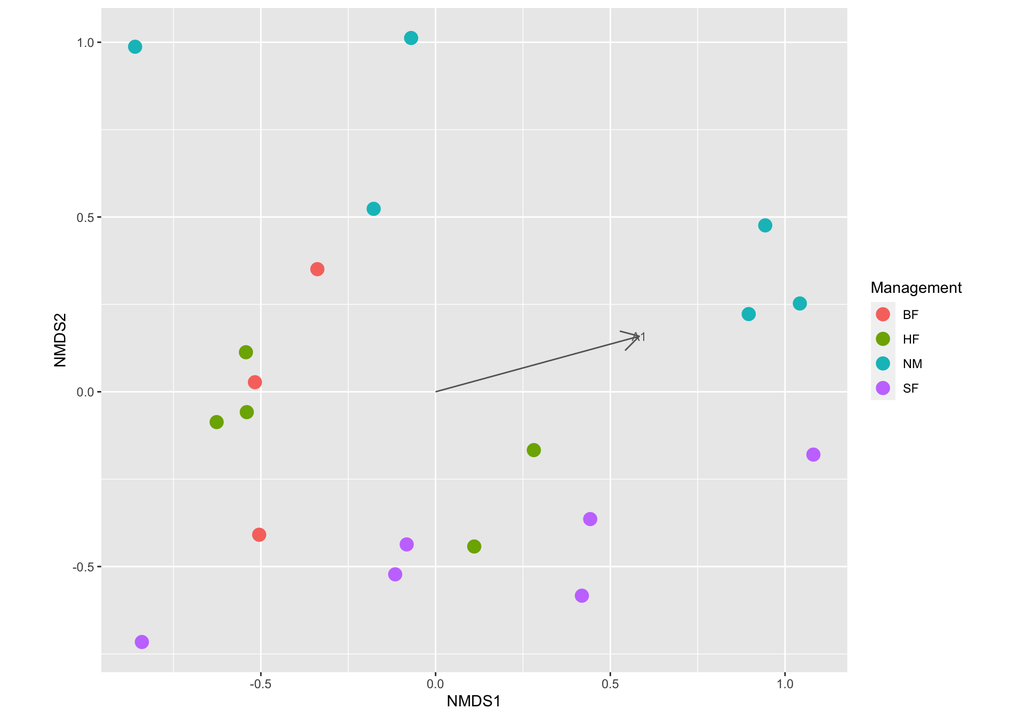

```r
p <- ggplot() +
  geom_point(data = dunePlot,
             aes(x = NMDS1, y = NMDS2,
                 color = Management),
             size = 4) +
  xlab("NMDS1") +
  ylab("NMDS2") +
  coord_fixed() + # fix axis ratio at 1, best practice for ordination plots
  geom_segment(data = vecPlot,
               aes(x = 0, xend = NMDS1,
                   y = 0, yend = NMDS2),
               arrow =
                 arrow(length = unit(0.5, "cm")),
               colour = "grey40") +
   geom_text(data = vecPlot,
            aes(x = NMDS1,
                y = NMDS2,
                label = Vname),
            color = 'grey40',
            size = 3)
p
```

### baseR

Let’s make the same plot in `baseR`

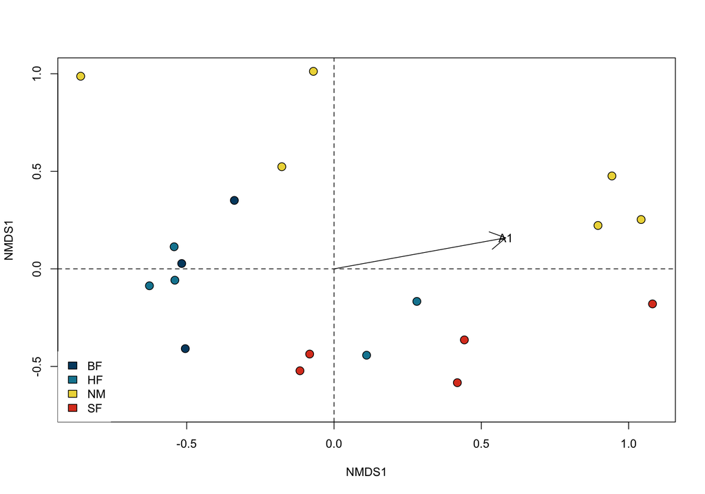

```r
# make palette for colors
my.pal <- pnw_palette(name = "Bay",
                      n = 4,
                      type = "discrete")
# make vector to hold colors from animal groups
my.cols <- my.pal[as.factor(dune.env$Management)]

# plot
plot(x = dunePlot$NMDS1,
     y = dunePlot$NMDS2,
     xlab = 'NMDS1',
     ylab = 'NMDS1',
     pch = 21,
     bg = my.cols,
     cex = 1.5)
# add vector arrow to plot
arrows(x0 = 0, x1 = vecPlot$NMDS1,
        y0 = 0, y1 = vecPlot$NMDS2)
# add vector names to plot
text(x = vecPlot$NMDS1,
    y = vecPlot$NMDS2,
     labels = vecPlot$Vname)
# add legend
legend('bottomleft',
       legend = levels(dune.env$Management),
       fill = my.pal,
       box.lty = 0)
# add vertical and horizontal dashed lines
abline(h = 0, lty = 2)
abline(v = 0, lty = 2)
```

### Ordisurf

As mentioned above, `envfit()` assumes fits a linear vector to the ordination space. In unconstrained ordination, the relationship between the ‘environmental’ variable and the space may not be linear, and rather than a vector, a surface may be more appropriate. `ordisurf()` fits a smooth surface for a a variable. Without worrying too much about the math behind this concept, we can use the function with the default and use the resulting plot to help us understand if the vector from `envfit()` was an acceptable simplification. In this case, the lines, which represent the contours of the plane, are almost exactly parallel, indicating that a vector is a very good simplification. In fact, let’s plot the arrow of our vector on top of the plot to see that relationship even better.

```r
my.surf <- ordisurf(dune.nmds ~ dune.env$A1,
         labcex = 1.2)
```

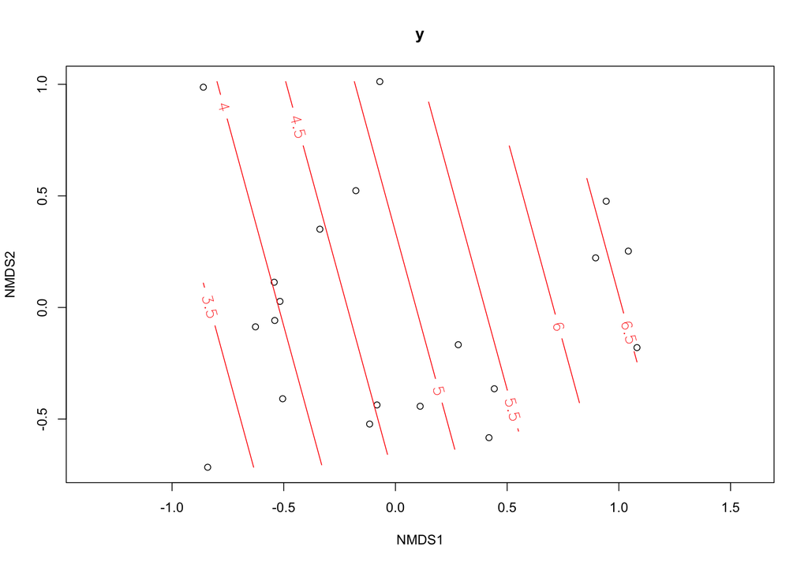

In fact, let’s plot the arrow of our vector on top of the plot to see that relationship even better. Excellent, we can see that it is exactly perpendicular.

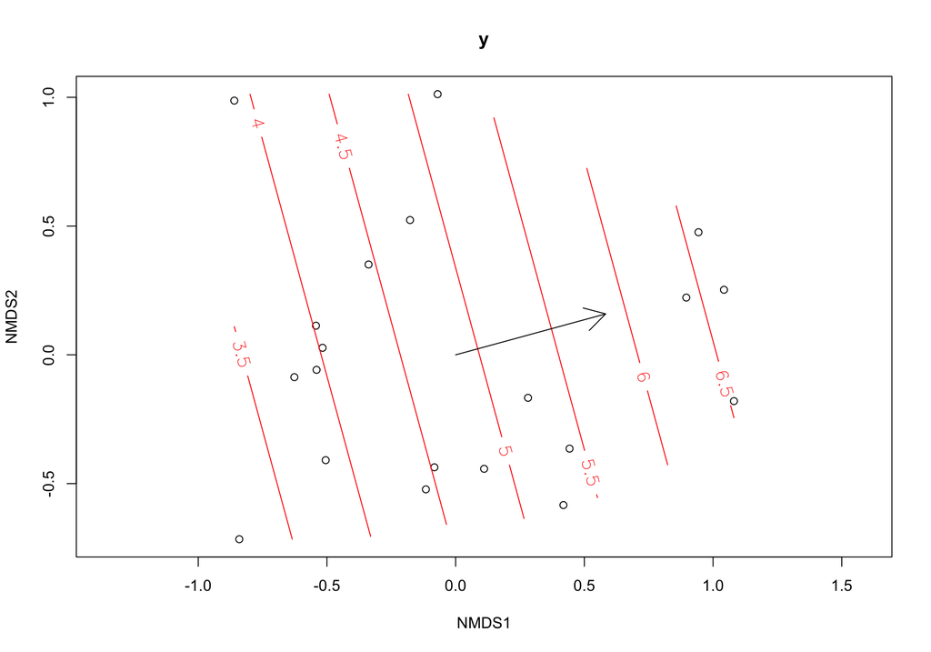

```r
my.surf <- ordisurf(dune.nmds ~ dune.env$A1,
         labcex = 1.2)
arrows(x0 = 0, x1 = vecPlot$NMDS1,
        y0 = 0, y1 = vecPlot$NMDS2)
```

Let’s make up a different variable that has a nonlinear relationship with the space just to see what a plot looks like when the ‘environmental’ variable has a nonlinear relationship with the ordination space. If this was the case, we may choose a different way to represent this variable in ordination space, like a continuous color scale.

```r
foo <- c(rnorm(5,1), rnorm(10,10),rnorm(5,2))
my.surf <- ordisurf(dune.nmds ~ foo)
```

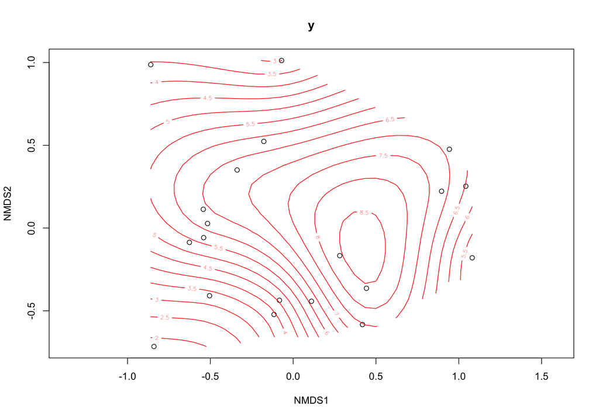

## Factors only

Let’s plot the NMDS with just the factor for Management. Here we will just add text to our plot.

### ggplot

We can see on these plots how each factor level is represented at the centroid of its sites.

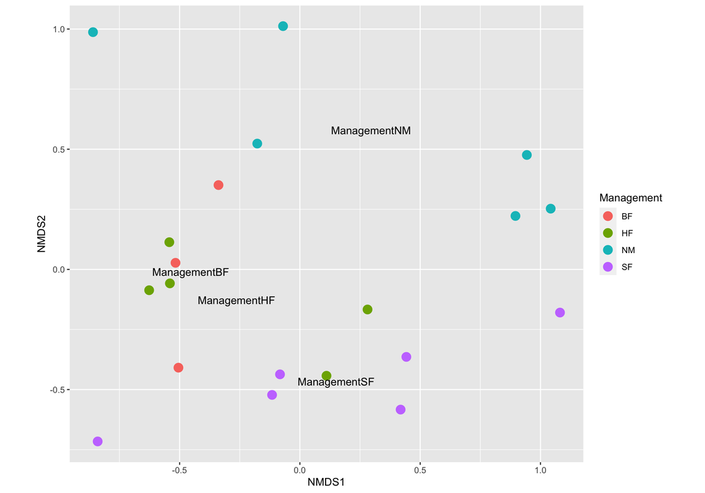

```r
p <- ggplot() +
  geom_point(data = dunePlot,
             aes(x = NMDS1, y = NMDS2,
                 color = Management),
             size = 4) +
  xlab("NMDS1") +
  ylab("NMDS2") +
  coord_fixed() +  # fix axis ratio at 1, best practice for ordination plots
  geom_text(data = facPlot,
            aes(x = NMDS1,
                y = NMDS2,
                label = Fname))
p
```

### baseR

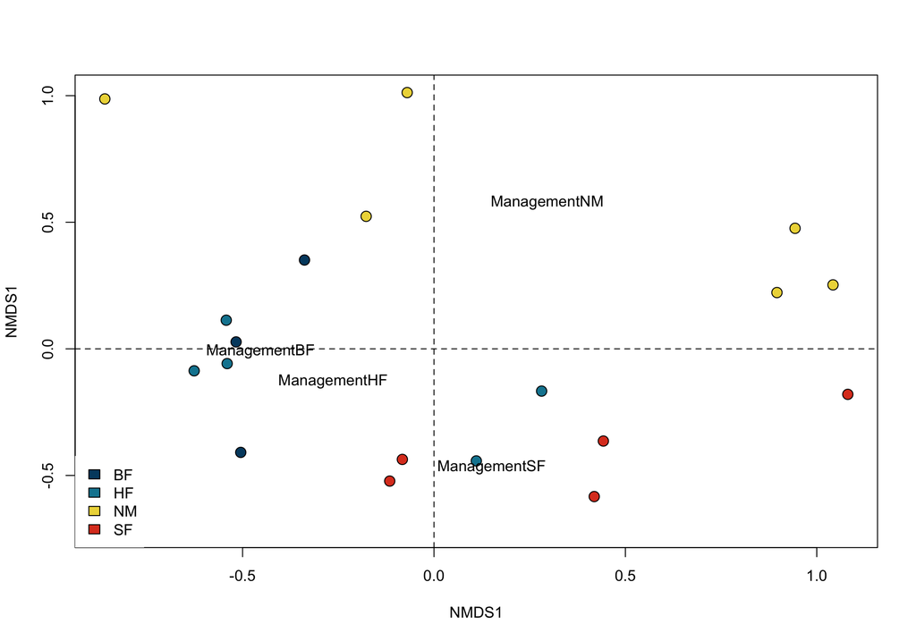

```r
# make palette for colors
my.pal <- pnw_palette(name = "Bay",
                      n = 4,
                      type = "discrete")
# make vector to hold colors from animal groups
my.cols <- my.pal[as.factor(dune.env$Management)]

plot(x = dunePlot$NMDS1,
     y = dunePlot$NMDS2,
     xlab = 'NMDS1',
     ylab = 'NMDS1',
     pch = 21,
     bg = my.cols,
     cex = 1.5)
# add factor levels to plot as text
text(x = facPlot$NMDS1,
     y = facPlot$NMDS2,
     labels = facPlot$Fname)
# add legend
legend('bottomleft',
       legend = levels(dune.env$Management),
       fill = my.pal,
       box.lty = 0)
# add vertical and horizontal dashed lines
abline(h = 0, lty = 2)
abline(v = 0, lty = 2)
```

# Additional Resources

The ‘vegan’ package is huge and really useful for analyzing community datasets. See the [full documentation](https://cran.r-project.org/web/packages/vegan/vegan.pdf) for more information about any of these functions or to see some of the other capabilities.  
There is also a relatively short [‘intro to vegan’ tutorial](https://rdrr.io/rforge/vegan/f/inst/doc/intro-vegan.pdf) that covers some of the same material presented here.

This is [a good nMDS Tutorial](https://jonlefcheck.net/2012/10/24/nmds-tutorial-in-r/). It walks through the steps of nMDS. Some of the content will be review for you. This tutorial also covers some plotting functions in ‘vegan’ that allow you to quickly overlay different predictor variables onto your plot without the hassle of creating color and shape vectors. These are not as beautiful as `ggplot()`, but really easy to implement and can be helpful when trying to understand your data.